# Problem Set 5 - Gapminder

## Introduction

This assignment is part of problem set 5 of the *Data Analysis with R* Udacity course’s lesson 5: *Explore Many Variables*.  
The task is to choose from the datasets available in the Gapminder website and, making use of the techniques from lesson 5, create 2-5 plot to study the data.

### The Dataset

For this study, two dataset were chosen from the Gapminder website.  
The first is a different subset of the same dataset used in problems sets 3 and 4 about *the average number of years of school attended by all people in the age and gender group specified, including primary, secondary and tertiary education*. This time the subset concerns women of reproductive age (15-44). The source of the data is the Institute for Health Metrics and Evaluation and it was uploaded in 2010.  
The second is a dataset of total fertility rate. That is, *the number of children that would be born to each woman with prevailing age-specific fertility rates*. This data was uploaded to the Gapminder website in 2009 and was revised in the 2 years that followed, with information from several sources. Theses sources are listed in the link below.

[Gapminder - Total Fertility Rate](https://spreadsheets.google.com/spreadsheet/pub?key=0ArfEDsV3bBwCdEdkaE5ZR1RHdHVud3prS0o5YVJoc0E&gid=1)

## Dataset Investigation and Observations

This chapter shows the tools and code used in the investigation of the dataset, as well as the observations and notes taken along the study.

### Data Wrangling

Load the raw two datasets:

```r
school.years <- read.csv('Years.in.school.women.15.44.csv', header = TRUE, check.names = FALSE)
names(school.years)[1] <- "country"

fertility.indicator <- read.csv('indicator.total.fertility.csv', header = TRUE, check.names = FALSE)
names(fertility.indicator)[1] <- "country"
```

Then, change the datasets to a more suitable structure.

```r
library(tidyr)
school.years.indicator <- gather(data = school.years, key = "year", value = "mean.num.years",
    2:length(school.years))

fertility.indicator.narrow <- gather(data = fertility.indicator, key = "year", value = "total.fertility",
                                     2:length(fertility.indicator))

# remove unnecessary data
rm(school.years)
rm(fertility.indicator)
```

Structure of the two datasets at this point.

```r
str(school.years.indicator)
```

```
## 'data.frame':    7000 obs. of  3 variables:
##  $ country       : Factor w/ 175 levels "Afghanistan",..: 1 2 3 4 5 6 7 8 9 10 ...
##  $ year          : Factor w/ 40 levels "1970","1971",..: 1 1 1 1 1 1 1 1 1 1 ...
##  $ mean.num.years: num  0.1 5.6 1.4 0.9 8.1 6.6 7.1 9.3 7.5 5.7 ...
```

```r
str(fertility.indicator.narrow )
```

```
## 'data.frame':    64740 obs. of  3 variables:
##  $ country        : Factor w/ 260 levels "Abkhazia","Afghanistan",..: 1 2 3 4 5 6 7 8 9 10 ...
##  $ year           : Factor w/ 249 levels "1545","1586",..: 1 1 1 1 1 1 1 1 1 1 ...
##  $ total.fertility: num  NA NA NA NA NA NA NA NA NA NA ...
```

Next, join the fertility rate dataset to the mean years in school dataset. Before the left join, a column was added to rule out a possible mismatch in country names or year, as these are the variables we will be using to join the two datasets.

```r
suppressMessages(library(dplyr))

## Add column to rule out mismatch between country names in join
fertility.indicator.narrow$miss.test <- 1

## left join school year with fertility indicator
sy.tf.indicator <- school.years.indicator %>%
  left_join(fertility.indicator.narrow, by = c("country", "year"))

## remove unnecessary data
rm(school.years.indicator)
rm(fertility.indicator.narrow)

## test possible mismatch and delete column
any(is.na(sy.tf.indicator$miss.test))
```

```
## [1] FALSE
```

```r
sy.tf.indicator$miss.test <- NULL

## how many values for fertility we are missing
table(!is.na(sy.tf.indicator$total.fertility))
```

```
##
## FALSE  TRUE
##    40  6960
```

#### Add region and continent information

Add information about region and continent to the dataset, as in problem set 4.

```r
library(countrycode)
data(countrycode_data)
str(countrycode_data)
```

```
## 'data.frame':    273 obs. of  15 variables:
##  $ country.name: chr  "Afghanistan" "Aland Islands" "Albania" "Algeria" ...
##  $ cowc        : chr  "AFG" NA "ALB" "ALG" ...
##  $ cown        : int  700 NA 339 615 NA 232 540 NA NA 58 ...
##  $ fao         : int  2 NA 3 4 NA 6 7 NA NA 8 ...
##  $ fips104     : chr  "AF" NA "AL" "AG" ...
##  $ imf         : int  512 NA 914 612 859 NA 614 312 NA 311 ...
##  $ ioc         : chr  "AFG" NA "ALB" "ALG" ...
##  $ iso2c       : chr  "AF" "AX" "AL" "DZ" ...
##  $ iso3c       : chr  "AFG" "ALA" "ALB" "DZA" ...
##  $ iso3n       : int  4 248 8 12 16 20 24 660 10 28 ...
##  $ un          : int  4 248 8 12 16 20 24 660 NA 28 ...
##  $ wb          : chr  "AFG" "ALA" "ALB" "DZA" ...
##  $ regex       : chr  "afghan" "\\b(a|å)land" "albania" "algeria" ...
##  $ continent   : chr  "Asia" "Europe" "Europe" "Africa" ...
##  $ region      : chr  "Southern Asia" "Northern Europe" "Southern Europe" "Northern Africa" ...
```

```r
## Countries with different names in the two datasets and their match
country.name.match <- read.csv("country.names.match.gapminder.codes.csv")
## Countries with the same name in both datasets
countries.with.matching.names <- sy.tf.indicator%>%
                                  anti_join(country.name.match, by="country") %>%
                                  select(country) %>%
                                  group_by(country) %>%
                                  summarise()

## Expand the dataset to include the match between countries with the same name
country.name.match <- country.name.match %>%
                        bind_rows(data.frame(countries.with.matching.names, countries.with.matching.names) %>%
                        setNames(c("country", "country.name")))

## Add region and continent to the original dataset
sy.tf.indicator <- sy.tf.indicator %>%
                  left_join(country.name.match , by="country") %>%
                  left_join(countrycode_data) %>%
                  select(country, year, mean.num.years, total.fertility, continent, region)
sy.tf.indicator$country <- as.factor(sy.tf.indicator$country)
sy.tf.indicator$continent <- as.factor(sy.tf.indicator$continent)
sy.tf.indicator$region <- as.factor(sy.tf.indicator$region)

## remove unnecessary data
rm(countrycode_data)
rm(countries.with.matching.names)
rm(country.name.match)
```

#### Add *year.as.numeric* and *decade* vars

The *year.as.numeric* var is the *year* var but as a numeric value, instead of categorical. The *decade* is a categorical variable of the 10 year interval a year is in.

```r
## year as numeric
sy.tf.indicator <-
  sy.tf.indicator %>%
  mutate(year.as.numeric = as.numeric(year))

## decade
sy.tf.indicator$decade <- as.factor(floor(as.numeric(sy.tf.indicator$year)/10) * 10)
```

### Mean Years in School

The metric *mean number of years in school* was the subject of previous problem sets and, although the subset is of a different size (previous concerned ages 25 to 34 only), the observations are very similar.

### Total Fertility Rate

This was the metric added to this study compared to the previous ones. Let’s study it first.

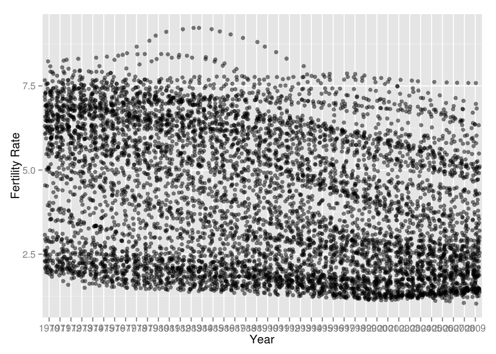

```r
suppressMessages(library(ggplot2))

ggplot(aes(x = year, y = total.fertility),
       data = subset(sy.tf.indicator, !is.na(total.fertility))) +
  geom_point(position = position_jitter(), alpha = 1/2) +
  ylab("Fertility Rate") +
  xlab("Year")
```

This is the evolution of the metric throughout the years. As is, the simple scatter plot is not very helpful. We can see some higher concentration of points for lower values of fertility, as well as, a concentration of points in higher values, but mostly in the first years.

#### Basic statistics

```r
summary(sy.tf.indicator$total.fertility)
```

```
##    Min. 1st Qu.  Median    Mean 3rd Qu.    Max.    NA's
##   1.030   2.154   3.790   4.070   5.924   9.223      40
```

#### Values by decade

```r
by(sy.tf.indicator$total.fertility,sy.tf.indicator$decade,summary)
```

```
## sy.tf.indicator$decade: 1970
##    Min. 1st Qu.  Median    Mean 3rd Qu.    Max.    NA's
##   1.463   2.843   5.540   4.962   6.686   8.843      10
## --------------------------------------------------------
## sy.tf.indicator$decade: 1980
##    Min. 1st Qu.  Median    Mean 3rd Qu.    Max.    NA's
##   1.314   2.318   4.508   4.409   6.250   9.223      10
## --------------------------------------------------------
## sy.tf.indicator$decade: 1990
##    Min. 1st Qu.  Median    Mean 3rd Qu.    Max.    NA's
##   1.140   1.946   3.308   3.729   5.299   8.667      10
## --------------------------------------------------------
## sy.tf.indicator$decade: 2000
##    Min. 1st Qu.  Median    Mean 3rd Qu.    Max.    NA's
##   1.030   1.780   2.641   3.180   4.449   7.733      10
```

The values have been decreasing throughout the decades.

#### Values by Countries

Lowest mean value per country:

```r
sy.tf.indicator %>%
  group_by(country) %>%
  summarise(mean = mean(total.fertility)) %>%
  arrange(mean)
```

```
## Source: local data frame [175 x 2]
##
##        country     mean
## 1      Germany 1.448225
## 2        Italy 1.551075
## 3      Austria 1.559250
## 4  Switzerland 1.559500
## 5   Luxembourg 1.607950
## 6        Japan 1.614425
## 7     Slovenia 1.652875
## 8  Netherlands 1.682725
## 9       Canada 1.685695
## 10      Russia 1.690700
## ..         ...      ...
```

Highest mean value per country:

```r
sy.tf.indicator %>%
  group_by(country) %>%
  summarise(mean = mean(total.fertility)) %>%
  arrange(desc(mean))
```

```
## Source: local data frame [175 x 2]
##
##        country     mean
## 1        Niger 7.680275
## 2  Yemen, Rep. 7.583625
## 3  Afghanistan 7.521700
## 4      Somalia 7.279100
## 5      Burundi 7.248200
## 6       Rwanda 7.108675
## 7         Chad 7.080950
## 8       Angola 7.022175
## 9       Uganda 6.953300
## 10        Mali 6.952825
## ..         ...      ...
```

#### Range

The rage of values refers to the difference of values between 1970 and 2009.

```r
diff.1970.2009 <- sy.tf.indicator %>%
  group_by(country) %>%
  arrange(year) %>%
  summarise(in.1970 = first(total.fertility), in.2009 = last(total.fertility)) %>%
  mutate(diff = in.2009 - in.1970)

table(diff.1970.2009$diff > 0)
```

```
##
## FALSE  TRUE
##   168     6
```

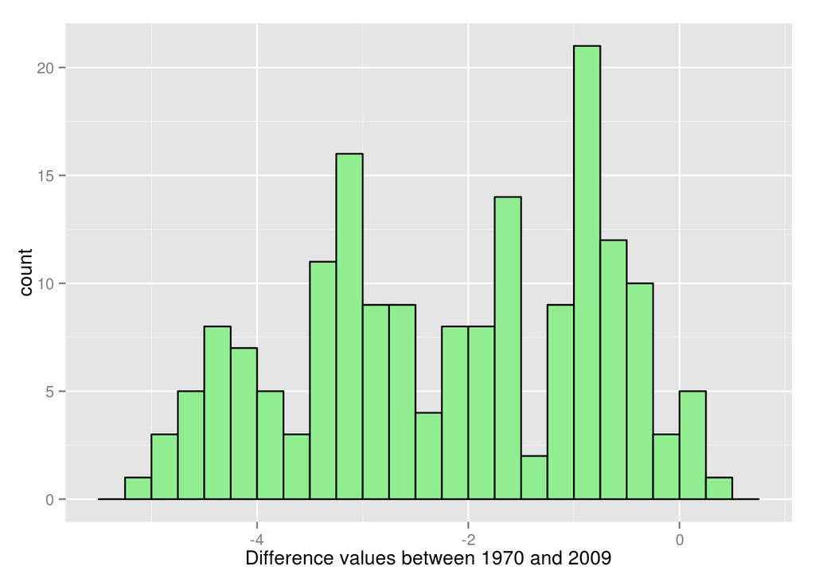

```r
ggplot(aes(x = diff), data = diff.1970.2009) +
  geom_histogram(color = 'black', fill='light green', binwidth = .25) +
  xlab("Difference values between 1970 and 2009")
```

With this indicator we can confirm the downwards tendency throughout the years, with only 6 countries increasing the value of fertility rate. Now, we look at these countries and also, the countries with the highest and lowest values of the difference.

```r
## Positive
diff.1970.2009 %>%
  arrange(desc(diff)) %>%
  filter(diff > 0)
```

```
## Source: local data frame [6 x 4]
##
##            country in.1970 in.2009  diff
## 1      Timor-Leste   5.917   6.360 0.443
## 2             Chad   6.528   6.702 0.174
## 3            Niger   7.422   7.585 0.163
## 4 Congo, Dem. Rep.   6.214   6.354 0.140
## 5          Finland   1.830   1.860 0.030
## 6           Sweden   1.919   1.937 0.018
```

```r
## Lowest values
diff.1970.2009 %>%
  arrange(abs(diff))
```

```
## Source: local data frame [175 x 4]
##
##             country in.1970 in.2009   diff
## 1            Sweden   1.919   1.937  0.018
## 2           Finland   1.830   1.860  0.030
## 3              Mali   6.901   6.830 -0.071
## 4           Denmark   1.950   1.842 -0.108
## 5  Congo, Dem. Rep.   6.214   6.354  0.140
## 6             Niger   7.422   7.585  0.163
## 7              Chad   6.528   6.702  0.174
## 8           Somalia   7.182   6.965 -0.217
## 9            Gambia   6.093   5.798 -0.295
## 10       Luxembourg   1.960   1.631 -0.329
## ..              ...     ...     ...    ...
```

```r
## Highest values
diff.1970.2009 %>%
  arrange(diff) %>%
  head()
```

```
## Source: local data frame [6 x 4]
##
##                country in.1970 in.2009   diff
## 1             Mongolia   7.569   2.410 -5.159
## 2             Maldives   7.227   2.360 -4.867
## 3              Algeria   7.641   2.781 -4.860
## 4                Qatar   6.918   2.133 -4.785
## 5 United Arab Emirates   6.605   1.903 -4.702
## 6           Bangladesh   6.947   2.322 -4.625
```

#### Mean Fertility Rate By Continent

Finally, we look at the mean fertility rate per continent.

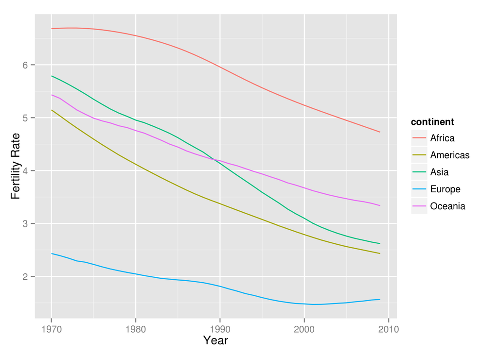

```r
ggplot(aes(x = year.as.numeric, y = total.fertility),
       data = subset(sy.tf.indicator, !is.na(total.fertility))) +
  geom_line(stat = "summary", fun.y = mean, aes(color = continent)) +
  ylab("Fertility Rate")+
  xlab("Year")
```

In this plot, we can see that Europe has the lowest rate in the 70’s and it’s value is very distant from the other continents.  
Then, until 2009, it’s the continent with the smallest decrease, although it remains the lowest value. The other continents dropped the values in a considerable way, approaching Europe’s values.  
The continent with the highest mean value in fertility rate is Africa, during these 4 decades.

### Fertility Rate vs. Year (and Decade)

In the next plots we look at the values of fertility rate throughout the time. First, against the year, then we divide the values into decade intervals and, finally, facet those values per continent.

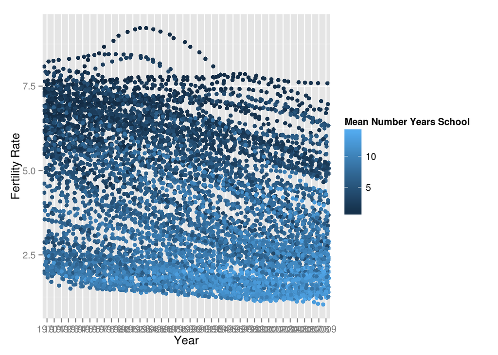

```r
ggplot(aes(x = year, y = total.fertility),
       data = subset(sy.tf.indicator, !is.na(total.fertility))) +
  geom_point(aes(color = mean.num.years), position = position_jitter()) +
  scale_colour_continuous(name="Mean Number Years School") +
  ylab("Fertility Rate")+
  xlab("Year")
```

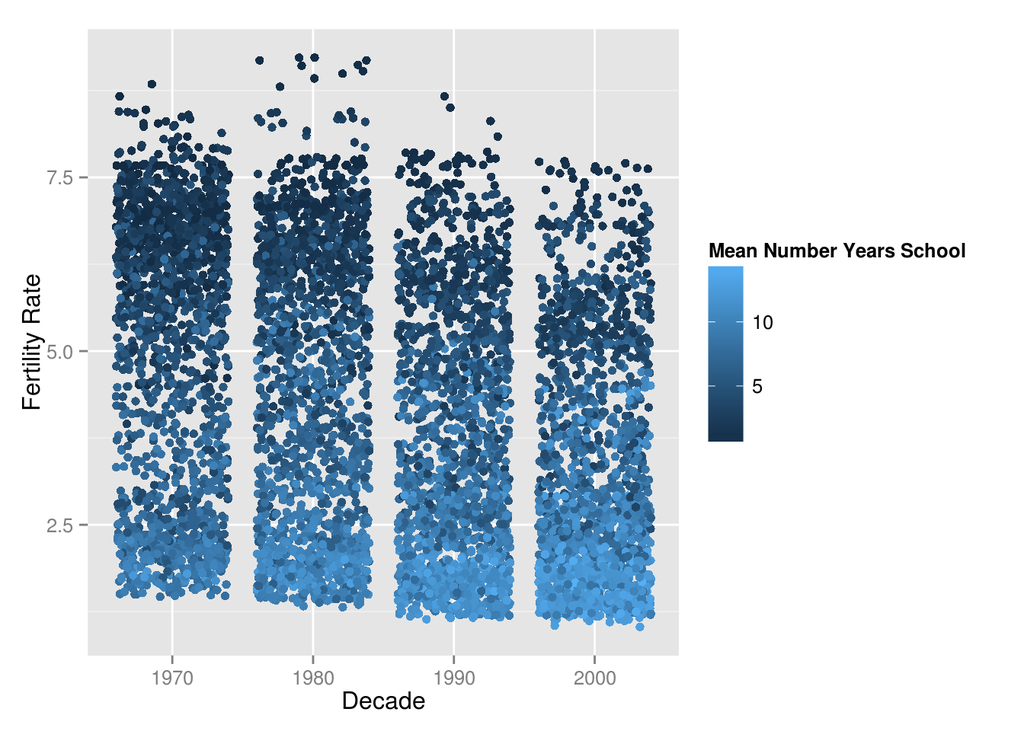

```r
ggplot(aes(x = decade, y = total.fertility),
       data = subset(sy.tf.indicator, !is.na(total.fertility))) +
  geom_point(aes(color = mean.num.years), position = position_jitter()) +
  scale_colour_continuous(name="Mean Number Years School") +
  ylab("Fertility Rate")+
  xlab("Decade")
```

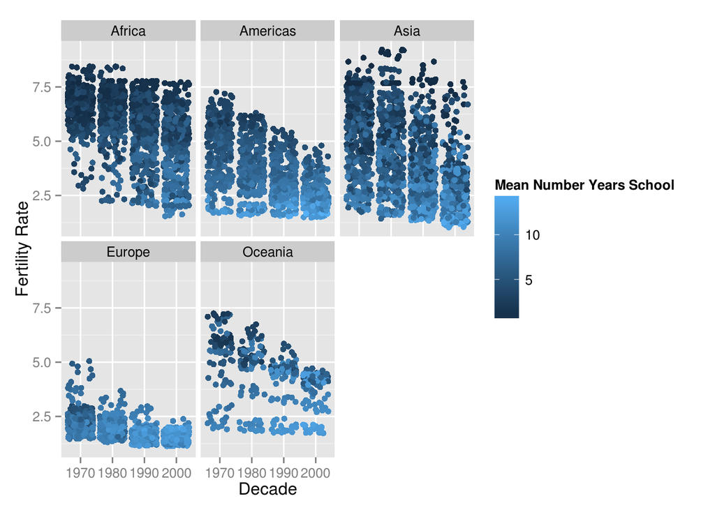

```r
ggplot(aes(x = decade, y = total.fertility),
       data = subset(sy.tf.indicator, !is.na(total.fertility))) +
  geom_point(aes(color = mean.num.years), position = position_jitter()) +
  facet_wrap(~continent) +
  scale_colour_continuous(name="Mean Number Years School") +
  ylab("Fertility Rate")+
  xlab("Decade")
```

### Mean Number Years in School vs. Year (and Decade)

The same exercise as in previous chapter, but with mean number of years in school values.

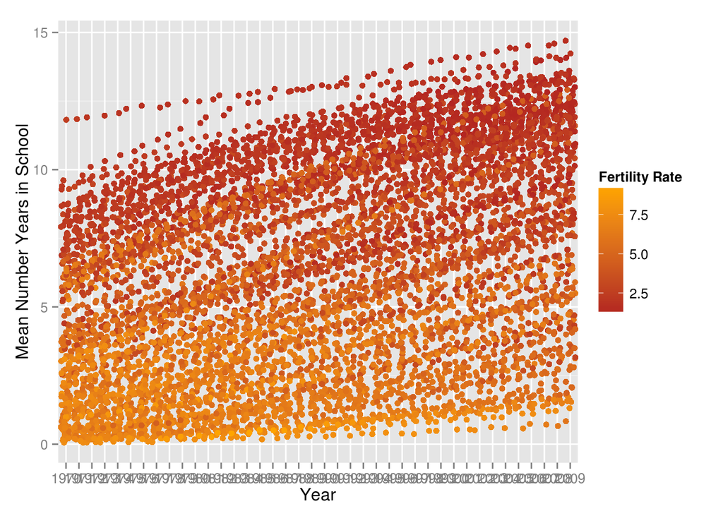

```r
ggplot(aes(x = year, y = mean.num.years),
       data = subset(sy.tf.indicator, !is.na(total.fertility))) +
  geom_point(aes(color = total.fertility), position = position_jitter()) +
  scale_colour_gradientn(colours=c("firebrick", "orange"), name="Fertility Rate") +
  ylab("Mean Number Years in School")+
  xlab("Year")
```

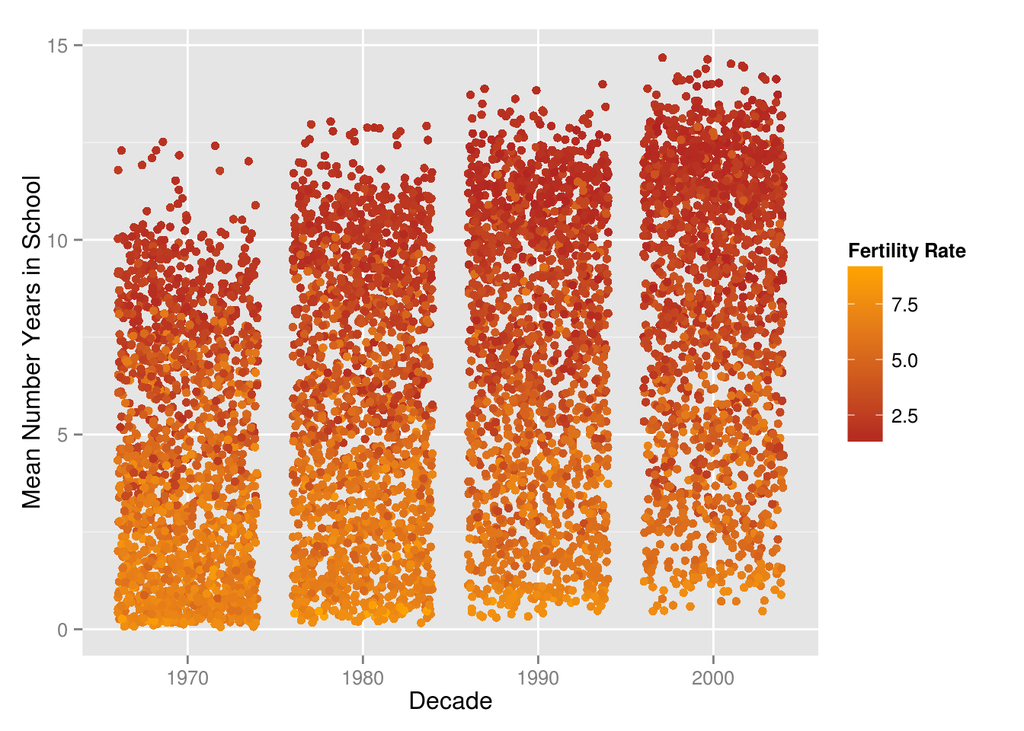

```r
ggplot(aes(x = decade, y = mean.num.years),
       data = subset(sy.tf.indicator, !is.na(total.fertility))) +
  geom_point(aes(color = total.fertility), position = position_jitter()) +
  scale_colour_gradientn(colours=c("firebrick", "orange"), name="Fertility Rate") +
  ylab("Mean Number Years in School")+
  xlab("Decade")
```

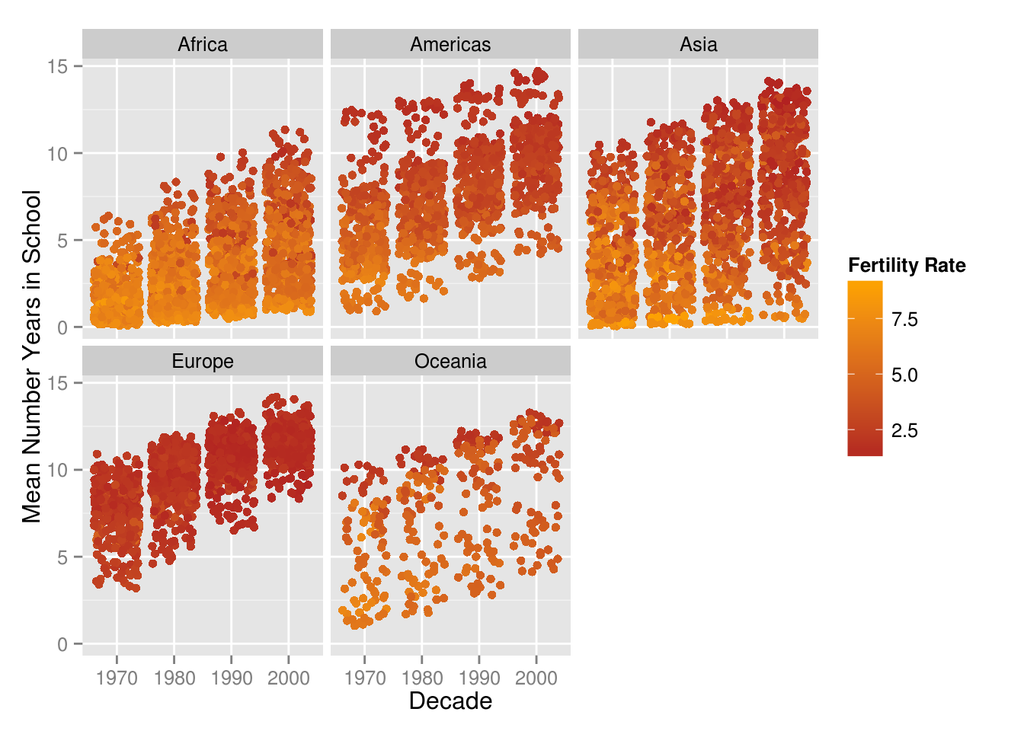

```r
ggplot(aes(x = decade, y = mean.num.years),
       data = subset(sy.tf.indicator, !is.na(total.fertility))) +
  geom_point(aes(color = total.fertility), position = position_jitter()) +
  facet_wrap(~continent) +
  scale_colour_gradientn(colours=c("firebrick", "orange"), name="Fertility Rate") +
  ylab("Mean Number Years in School")+
  xlab("Decade")
```

### Fertility Rate vs. Mean Number Years in School

Finally we take a look at fertility rate vs mean number of years. First, we try a simple scatter plot with a smooth line and, then, we add some color according to the year.

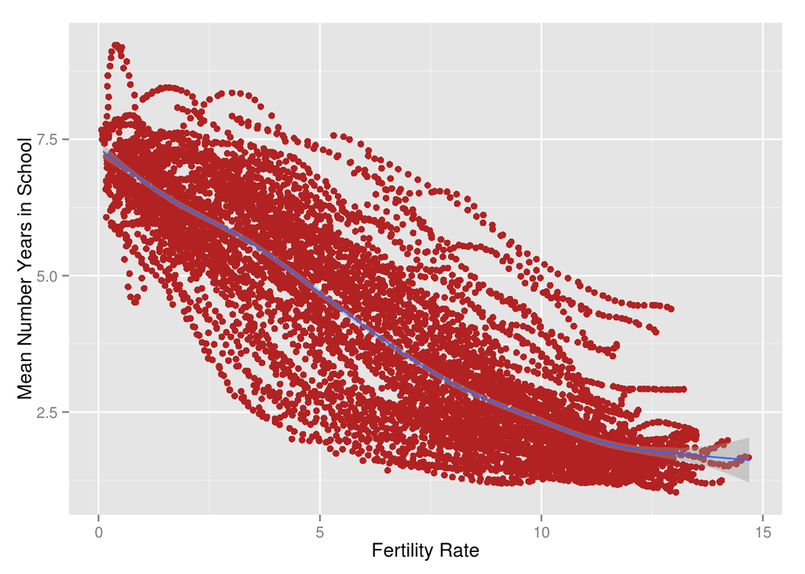

```r
ggplot(aes(x = mean.num.years, y = total.fertility),
       data =  subset(sy.tf.indicator, !is.na(total.fertility))) +
  geom_point(color = 'firebrick', position = position_jitter()) +
  geom_smooth() +
  xlab("Fertility Rate")+
  ylab("Mean Number Years in School")
```

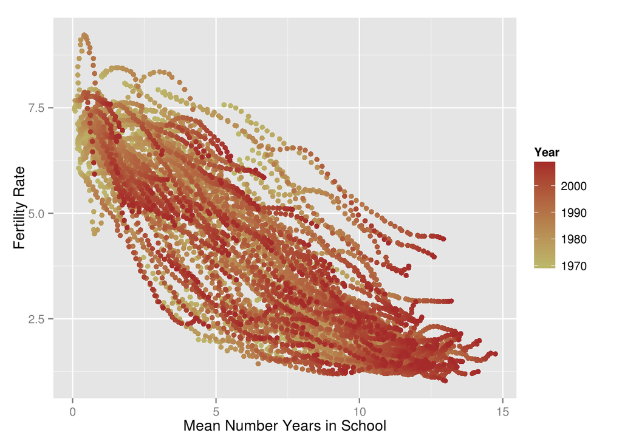

```r
ggplot(aes(x = mean.num.years, y = total.fertility),
       data =  subset(sy.tf.indicator, !is.na(total.fertility))) +
  geom_point(aes(color = year.as.numeric), position = position_jitter()) +
  scale_color_gradient(low="darkkhaki", high="brown", name = "Year")+
  ylab("Fertility Rate")+
  xlab("Mean Number Years in School")
```

Looking at the scatter plot and the smooth line added, we can observe the nearly linear negative relationship between the two values.

#### Difference between 1970 and 2009

Let’s plot the differences in this relationship between the years of 1970 and 2009, and separate it by continent, as that evolution is different between them.

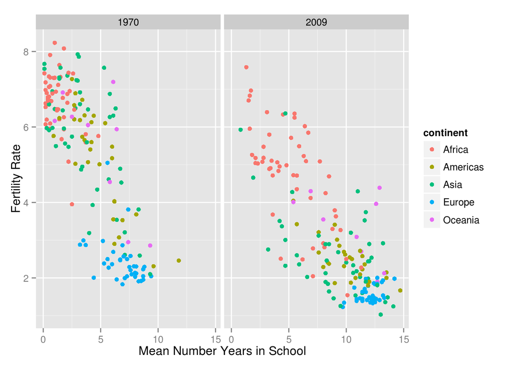

```r
ggplot(aes(y = total.fertility, x = mean.num.years),
       data =  subset(sy.tf.indicator, !is.na(total.fertility) & year %in% c(1970,2009))) +
  geom_point(aes(color = continent)) +
  facet_wrap(~year) +
  ylab("Fertility Rate") +
  xlab("Mean Number Years in School")
```

#### Discrete Fertility Rate

Here the values for fertility rate are transformed and distributed into buckets/intervals of 1 unit. We use the year to color the scatter plot.  
For this plot there is also a change in the axis, so that fertility rate is now in the x axis.

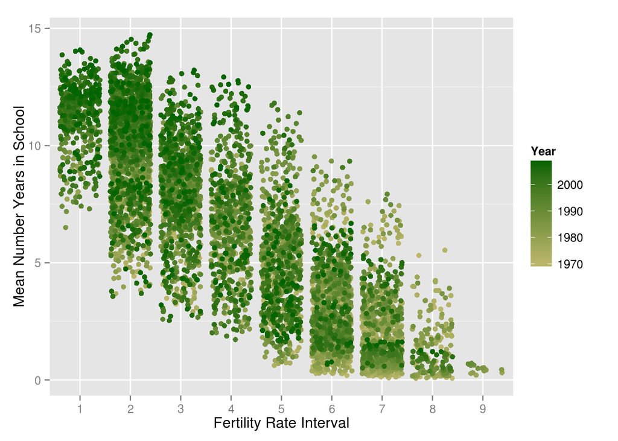

```r
ggplot(aes(x = as.factor(round(total.fertility)), y = mean.num.years),
       data =  subset(sy.tf.indicator, !is.na(total.fertility))) +
  geom_point(aes(color = year.as.numeric), position = position_jitter()) +
  scale_color_gradient(low="darkkhaki", high="darkgreen", name="Year") +
  xlab("Fertility Rate Interval")+
  ylab("Mean Number Years in School")
```

#### Correlation

The Pearson’s correlation value between the two variables.

```r
cor.test(sy.tf.indicator$mean.num.years, sy.tf.indicator$total.fertility)
```

```
##
##  Pearson's product-moment correlation
##
## data:  sy.tf.indicator$mean.num.years and sy.tf.indicator$total.fertility
## t = -138.0351, df = 6958, p-value < 2.2e-16
## alternative hypothesis: true correlation is not equal to 0
## 95 percent confidence interval:
##  -0.8620257 -0.8494515
## sample estimates:
##       cor
## -0.855865
```

The value is appoximatly -0.86 which indicates a strong negative relationship.

#### Highest Mean Number of Years in School And Lowest Mean Fertility Rate

Looking at the values for each region in the world, we can also observe that the regions with the highest values for mean number of years spend in school are also among the regions with the lowest mean values for fertility rate.

Regions with highest mean number of years in school:

```r
sy.tf.indicator %>%
  group_by(region) %>%
  summarise(mean.school = mean(mean.num.years), mean.fertility = mean(total.fertility)) %>%
  arrange(desc(mean.school)) %>%
  head(8)
```

```
## Source: local data frame [8 x 3]
##
##                      region mean.school mean.fertility
## 1          Northern America    12.79625       1.823722
## 2 Australia and New Zealand    10.96750       2.103037
## 3           Northern Europe    10.92167       1.860966
## 4            Eastern Europe    10.63875       1.815610
## 5            Western Europe     9.95000       1.637725
## 6                 Polynesia     9.88000       5.132837
## 7              Central Asia     9.53050       3.951300
## 8              Eastern Asia     9.10800       2.549822
```

Regions with lowest mean fertility rate:

```r
sy.tf.indicator %>%
  group_by(region) %>%
  summarise(mean.school = mean(mean.num.years), mean.fertility = mean(total.fertility)) %>%
  arrange(mean.fertility) %>%
  head(8)
```

```
## Source: local data frame [8 x 3]
##
##                      region mean.school mean.fertility
## 1            Western Europe    9.950000       1.637725
## 2            Eastern Europe   10.638750       1.815610
## 3          Northern America   12.796250       1.823722
## 4           Northern Europe   10.921667       1.860966
## 5           Southern Europe    8.355227       1.946936
## 6 Australia and New Zealand   10.967500       2.103037
## 7              Eastern Asia    9.108000       2.549822
## 8                 Caribbean    8.333125       3.173359
```

## Conclusion

With this study we were able to observe:

1. The fertility rate value and its evolution in time, as well, as its differences between continents.
2. The mean number of years in school values and evolution in the different decades and continents.
3. The fertility rate vs. mean number of years in school relationship, as well as its evolution through the years. We also determined that this relationship has a correlation value of -0.86 and it can be roughly represented by a linear negative model.

Sara Carvalho 12-03-2015